# Where Is America Growing?

County population change and the geography of domestic migration, 2020-2025

Xusijie

2026-10-18

Between 2020 and 2025, U.S. population change was not spread evenly across space. This article asks two connected questions: **where did county populations grow or shrink, and how closely did those changes line up with domestic migration?**

## Why geography matters

Population change affects local tax bases, labor markets, housing demand, school enrollment, and infrastructure needs. A national growth rate hides the fact that one county can be adding residents while another is losing them. Mapping the change lets us see whether growth forms regional clusters rather than isolated local exceptions.

I use the U.S. Census Bureau’s [Vintage 2025 Population Estimates](https://www.census.gov/data/tables/time-series/demo/popest/2020s-counties-total.html), which provide consistent county population estimates and components of change from 2020 through 2025. County and state geometry comes from the Census Bureau’s [2025 Cartographic Boundary Files](https://www.census.gov/geographies/mapping-files/time-series/geo/cartographic-boundary.html). The script downloads both sources directly and joins them using the five-digit county GEOID.

The analysis focuses on the contiguous United States so Alaska and Hawaii do not have to be resized or repositioned in ways that obscure distance and area. Their observations remain in the original Census file but are excluded from the processed analytical sample.

## 1. Growth formed clear regional clusters

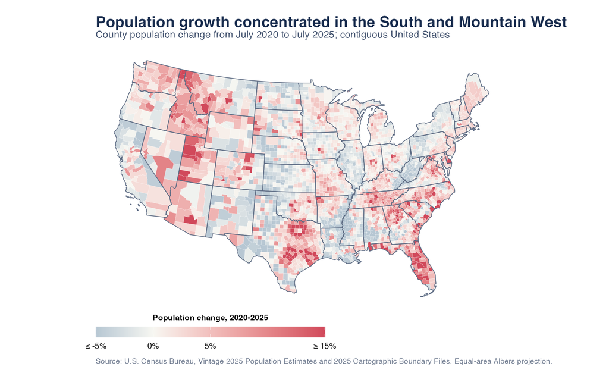

The first map reports the percentage change in each county’s estimated population between July 2020 and July 2025:

$$\text{growth rate} = 100 \times
\left(\frac{\text{population}_{2025}}{\text{population}_{2020}} -
1\right).$$

Growth is visibly clustered rather than randomly scattered. A broad arc of faster-growing counties runs through Florida, the Carolinas, Tennessee, Texas, and the Mountain West. Many declining counties appear in parts of the Great Plains, the Mississippi Delta, Appalachia, and the industrial Midwest. Metropolitan edges also often grew faster than nearby central or rural counties, although that pattern is not universal.

Across the 3109 counties and county equivalents in the sample, **60% gained population**, and the median county grew by **1.1%**. Those national summaries are modest, but the map shows why an average is incomplete: fast growth and decline were geographically concentrated.

Among counties with at least 20,000 residents, **Kaufman County, Texas grew by 42.2%**, while **Yazoo County, Mississippi changed by -14%**. The population cutoff is used only for these examples and the scatterplot labels; the map includes every county and county equivalent in the contiguous states.

These clusters matter economically. Sustained population gains can expand the labor force and consumer base but can also increase pressure on housing and infrastructure. Persistent losses can weaken local demand and make it harder to spread the fixed costs of schools, roads, and public services across residents. The map identifies where those pressures are likely to differ; it does not by itself explain why they occurred.

## 2. Domestic migration followed much of the same geography

Population changes through births, deaths, international migration, and movement between U.S. counties. To isolate the last component, I average the Census Bureau’s annual net domestic migration rate from 2020-21 through 2024-25. The rate is measured per 1,000 residents, which makes counties of different sizes comparable.

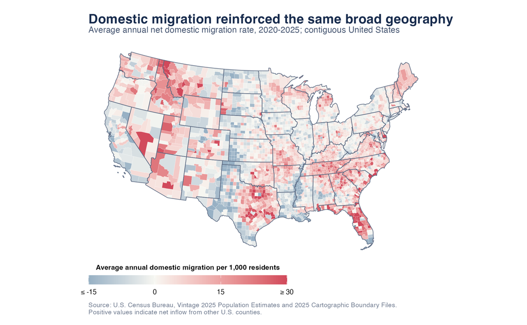

The migration map resembles the growth map in important ways. Many fast-growing counties in Florida, Texas, the Carolinas, Tennessee, and the interior West also received more residents from elsewhere in the country than they lost. Conversely, several counties around large urban centers and across northern regions recorded net domestic outflows.

But the two maps are not identical. A county can lose residents to other U.S. counties and still grow through international migration or natural increase (births minus deaths). It can also attract domestic migrants without growing rapidly if deaths exceed births. Domestic migration is therefore one mechanism in the population accounting identity, not a complete explanation of county growth.

## 3. Migration explains much of the pattern, but not all of it

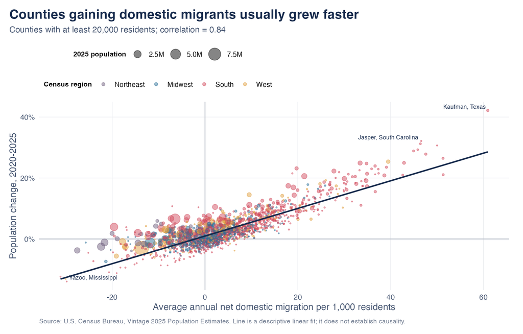

For counties with at least 20,000 residents, the correlation between the average annual domestic migration rate and five-year population growth is **0.84**. The upward-sloping fitted line summarizes the relationship: counties with larger domestic inflows generally grew faster.

The cutoff reduces extreme percentage changes caused by very small denominators, but it does not change the mapped sample. Point size represents 2025 population, and color identifies the Census region. The regional colors reinforce what the maps show: many Southern and Western counties occupy the upper-right portion of the plot, while many Northeastern and Midwestern counties fall closer to zero growth or into the outflow half.

The remaining vertical spread is substantively important. Counties with similar domestic migration rates can have different overall growth because international migration and natural change also differ. The fitted line is descriptive and should not be interpreted as a causal effect of migration: employment growth, housing supply, amenities, taxes, climate, and population movement may influence one another.

## Takeaway

The maps reveal a geographic redistribution of population toward much of the South and Mountain West between 2020 and 2025, alongside decline in many counties in the Midwest, Great Plains, Appalachia, and Mississippi Delta. The domestic migration map and scatterplot show that movement within the United States was closely connected to this redistribution.

The key lesson is not simply that some counties grew and others shrank. It is that **population growth formed regional clusters, and domestic migration reinforced those clusters without fully determining them**. Places receiving new residents may need additional housing and infrastructure, while places losing residents face a different challenge: maintaining services and economic opportunity with a smaller population base.

## Methods, limitations, and reproducibility

All results are generated by `analysis.R`. The script downloads the Census CSV and KML files, retains county-level observations, calculates five-year population growth and annualized component rates, parses geographic coordinates, applies an equal-area Albers projection, joins attributes to boundaries by GEOID, and saves every figure and processed file.

Map colors are capped at -5% to 15% for population change and -15 to 30 per 1,000 for domestic migration so a few extreme counties do not flatten meaningful variation elsewhere. Capping affects only the displayed color; the processed CSV preserves exact values. Cartographic boundaries are simplified for national-scale mapping and should not be used for surveying or parcel-level work.

Population estimates are revised with each annual vintage, so later downloads may produce slightly different values. Estimates are not exact headcounts, and county-level patterns do not describe every neighborhood or household within a county. The analysis covers 2020-2025 and should not be treated as evidence about longer-run trends without examining earlier periods.

**Data accessed:** October 18, 2026. **Sources:** U.S. Census Bureau Population Estimates Program and 2025 Cartographic Boundary Files. See the README for exact replication and GitHub Pages instructions.